# FW472 Learning Activity 4

YOUR FIRST AND LAST NAME HERE!

Spring 2024

## Learning Objectives

- Introduction to the EPA National Lakes Assessment
- Converting biotic community data into the site x species format
- Merging data based on shared columns
- Display of multidimensional biotic community data using ordination techniques

## Overview and Data

We are working with four different data files:

2017 NLA Phytoplankton counts and biomass (long data): “nla_2017_phytoplankton_count-data.csv”

2017 NLA Zooplankton counts and biomass (long data): “nla-2017-zooplankton-count-data.csv”

2017 NLA lake site information: “nla_2017_site_information-data.csv”

2017 NLA water chemistry data for a 100 lake subset that has been cleaned (wide format): “NLA_2017_Chemistry_Subset.csv”

You can check out other data and metadata for the NLA alongside the rest of the [National Aquatic Resources Survey](https://www.epa.gov/national-aquatic-resource-surveys/data-national-aquatic-resource-surveys)

In the pre-exercise section, I will go through an ordination example using the phytoplankton data and then your guided exercise will use the zooplankton data.

Let’s bring in our required packages:

```r
library(reshape2) # Package to convert data from wide to long format, and vice versa
library(vegan) # Package containing ordination methods
library(ggplot2) # Plotting functions
library(ggforce) # Add-on for plotting hulls around data
library(concaveman) # Add-on for plotting hulls around data
```

## Data Preparation and Merging

First, let’s read in the NLA 2017 data for phytoplankton. You can see that this data is in “long” format where there are multiple rows for each Unique ID (UID) for each lake. Each row represents one taxon’s data collected for a lake. This means that we have to look across multiple rows to determine all of the phytoplankton taxa sampled in the lake. The benefit of this format is that we can store multiple values per each taxa. For example, here the NLA reports the abundance, biovolume, and density of each taxa.

```r
phyto <- read.csv("nla_2017_phytoplankton_count-data.csv")
head(phyto)
```

```
##   PUBLICATION_DATE     UID        SITE_ID  DATE_COL VISIT_NO STATE STUDY
## 1        4/12/2021 2010177 NLA17_NV-10018 5/30/2017        1    NV   NLA
## 2        4/12/2021 2010177 NLA17_NV-10018 5/30/2017        1    NV   NLA
## 3        4/12/2021 2010177 NLA17_NV-10018 5/30/2017        1    NV   NLA
## 4        4/12/2021 2010177 NLA17_NV-10018 5/30/2017        1    NV   NLA
## 5        4/12/2021 2010177 NLA17_NV-10018 5/30/2017        1    NV   NLA
## 6        4/12/2021 2010177 NLA17_NV-10018 5/30/2017        1    NV   NLA
##   SITETYPE LAT_DD83  LON_DD83 SAMPLE_TYPE SAMPLE_ID TAXA_ID ABUNDANCE BIOVOLUME
## 1     PROB 39.54188 -119.7789        PHYX    834967    4559        52    611000
## 2     PROB 39.54188 -119.7789        PHYX    834967    4194        15    101000
## 3     PROB 39.54188 -119.7789        PHYX    834967    4186         8     15300
## 4     PROB 39.54188 -119.7789        PHYX    834967    4557         3    262000
## 5     PROB 39.54188 -119.7789        PHYX    834967    5221        10      2440
## 6     PROB 39.54188 -119.7789        PHYX    834967    4554         1    336000
##   DENSITY ANALYST_NAME  ALGAL_GROUP                TARGET_TAXON      PHYLUM
```

[output cut: 20 more lines]

Next, let’s clean up the data subset that we want to work with. Let’s pull out from the whole dataset the lake UID, the biovolume, and the algal group and genus. You’ll notice here that instead of putting in NAs, cells were left blank if an algal group or genus was not assigned. For example, a taxon may have been identified to a higher level and genus was left empty.

```r
phyto_simp <- phyto[ ,c("UID", "BIOVOLUME", "ALGAL_GROUP", "GENUS")]
head(phyto_simp)
```

```
##       UID BIOVOLUME  ALGAL_GROUP         GENUS
## 1 2010177    611000 CRYPTOPHYTES  PLAGIOSELMIS
## 2 2010177    101000  GREEN ALGAE CHLAMYDOMONAS
## 3 2010177     15300  GREEN ALGAE        ANKYRA
## 4 2010177    262000 CRYPTOPHYTES   CRYPTOMONAS
## 5 2010177      2440  GREEN ALGAE   PEDINOMONAS
## 6 2010177    336000 CRYPTOPHYTES   CRYPTOMONAS
```

```r
sum(is.na(phyto_simp$ALGAL_GROUP))
```

```
## [1] 0
```

```r
sum(is.na(phyto_simp$GENUS))
```

```
## [1] 0
```

```r
sum(phyto_simp$ALGAL_GROUP == "")
```

```
## [1] 663
```

```r
sum(phyto_simp$GENUS == "")
```

```
## [1] 28
```

This line of code will remove those blank values for algal group in the same way we removed NAs before.

```r
phyto_simp <- phyto_simp[!phyto_simp$ALGAL_GROUP == "",]
```

We can now use the dcast() function to cast our data from long format to wide. We first specify the data we are manipulating, then add the formula for the cast. Here, we want a wide dataframe of site by species or lake UID ~ ALGAL_GROUP. We specify our value variable, which is biovolume and then a function for aggregating the data if there are multiple values such as sum Because ALGAL_GROUP are our broad categories like blue-green algae or diatoms, we have to specify what we want to do with multiple taxa within the group. Taking the sum makes sense here since we want to get the total biovolume of each group by lake.

```r
phyto_site_sp <- dcast(phyto_simp, UID ~ ALGAL_GROUP,  na.rm = TRUE, value.var = "BIOVOLUME", fun.aggregate = sum)
head(phyto_site_sp)
```

```
##       UID BLUE-GREEN ALGAE CRYPTOPHYTES  DIATOM DINOFLAGELLATES EUGLENOIDS
## 1 2010177            18810      2579000   14600               0          0
## 2 2010178           261142       346000 9061300               0          0
## 3 2010179           110690       920000  185000               0          0
## 4 2010180             1610        30600    7540               0          0
## 5 2010181             5240       742000       0               0          0
## 6 2010182         11601400      6050000       0               0          0
##   GOLDEN ALGAE GREEN ALGAE YELLOW-GREEN ALGAE
## 1         2340      210880                  0
## 2       126300   173978350                  0
## 3      1040000     1644200                  0
## 4         4730        1903                  0
## 5     38612000       37340                  0
## 6            0     1053000                  0
```

You can also take a wide data frame and covert it back to long. An example of this conversion back to long is shown below, which we will not use here.

```r
head(melt(phyto_site_sp,id.vars = c("UID")))
```

```
##       UID         variable    value
## 1 2010177 BLUE-GREEN ALGAE    18810
## 2 2010178 BLUE-GREEN ALGAE   261142
## 3 2010179 BLUE-GREEN ALGAE   110690
## 4 2010180 BLUE-GREEN ALGAE     1610
## 5 2010181 BLUE-GREEN ALGAE     5240
## 6 2010182 BLUE-GREEN ALGAE 11601400
```

Next, we will replace all NA values in our site by species matrix with 0. In this case, if a lake UID did not have any of that algal group sampled then it is not actually missing data but a true 0. Since we applied na.rm = TRUE above, we already have 0 in our data but I am including this in case you later need to manually replace your NAs.

```r
phyto_site_sp <- replace(phyto_site_sp,is.na(phyto_site_sp),0)
head(phyto_site_sp)
```

```
##       UID BLUE-GREEN ALGAE CRYPTOPHYTES  DIATOM DINOFLAGELLATES EUGLENOIDS
## 1 2010177            18810      2579000   14600               0          0
## 2 2010178           261142       346000 9061300               0          0
## 3 2010179           110690       920000  185000               0          0
## 4 2010180             1610        30600    7540               0          0
## 5 2010181             5240       742000       0               0          0
## 6 2010182         11601400      6050000       0               0          0
##   GOLDEN ALGAE GREEN ALGAE YELLOW-GREEN ALGAE
## 1         2340      210880                  0
## 2       126300   173978350                  0
## 3      1040000     1644200                  0
## 4         4730        1903                  0
## 5     38612000       37340                  0
## 6            0     1053000                  0
```

We are now ready to bring in our water chemistry data to merge. This subset has already been cleaned for 100 lakes so that you can work with this file directly in wide format.

```r
chem <- read.csv("NLA_2017_Chemistry_Subset.csv")
head(chem)
```

```
##       UID AMMONIA_N NITRATE_N   CHLA   PH   DOC SILICA  TURB
## 1 2010177     0.599    0.1623   5.19 7.95  7.72  6.996  3.16
## 2 2010178     0.027    0.0196  12.16 8.45  7.12 33.686  2.72
## 3 2010179     0.014    0.0507   6.14 8.92 27.17 14.273  2.68
## 4 2010180     0.086    1.0637   0.60 9.40 62.55  2.726  0.68
## 5 2010181     0.051    0.0995 305.28 7.90  6.92  1.310 10.57
## 6 2010184     0.019    0.0011   2.74 8.45  5.29  1.096  1.05
```

```r
phyto_site_sp <- phyto_site_sp[phyto_site_sp$UID %in% chem$UID, ]
```

We can now use a new function merge() to combine these two data sets based on a shared column ID. For the NLA data, all lakes are coded by a unique identifier (UID) that can be used to join the different data sets to one another. In order to do this we have to specify what the two merged data sets are being joined by with “by =”, in this case the UID. If you are familiar with dplyr or other R packages, then you can also use one of the many other functions that can be used to join data. Merging in R or other programs is much less error prone and more efficient since you don’t have to sort or organize the data yourself as in Excel.

Here, we are specifying that we want to merge the chem data set and the phyto_site_sp dataset by the UID.

```r
phyto_chem <- merge(chem, phyto_site_sp, by = "UID")
head(phyto_chem)
```

```
##       UID AMMONIA_N NITRATE_N   CHLA   PH   DOC SILICA  TURB BLUE-GREEN ALGAE
## 1 2010177     0.599    0.1623   5.19 7.95  7.72  6.996  3.16            18810
## 2 2010178     0.027    0.0196  12.16 8.45  7.12 33.686  2.72           261142
## 3 2010179     0.014    0.0507   6.14 8.92 27.17 14.273  2.68           110690
## 4 2010180     0.086    1.0637   0.60 9.40 62.55  2.726  0.68             1610
## 5 2010181     0.051    0.0995 305.28 7.90  6.92  1.310 10.57             5240
## 6 2010184     0.019    0.0011   2.74 8.45  5.29  1.096  1.05             7440
##   CRYPTOPHYTES  DIATOM DINOFLAGELLATES EUGLENOIDS GOLDEN ALGAE GREEN ALGAE
## 1      2579000   14600               0          0         2340      210880
## 2       346000 9061300               0          0       126300   173978350
## 3       920000  185000               0          0      1040000     1644200
## 4        30600    7540               0          0         4730        1903
## 5       742000       0               0          0     38612000       37340
## 6       684000  622000               0          0       218000       49900
##   YELLOW-GREEN ALGAE
## 1                  0
## 2                  0
## 3                  0
## 4                  0
## 5                  0
## 6                  0
```

Now we have a 16 column dataset that has both our algal groups and water chemistry measurements by lake. Now we can do things like plot our biomasses by water chemistry variables such as whether higher chlorophyll (more eutrophic) lakes have greater cyanobacterial biomass:

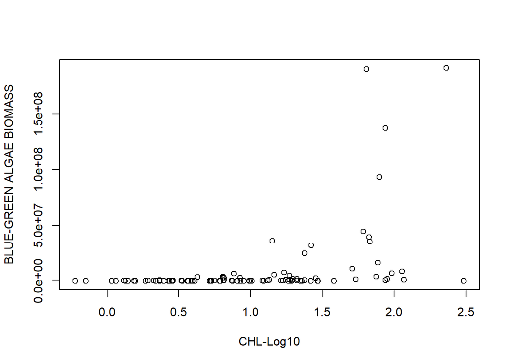

```r
plot(log10(phyto_chem$CHLA), phyto_chem$`BLUE-GREEN ALGAE`, xlab = "CHL-Log10", ylab = "BLUE-GREEN ALGAE BIOMASS")
```

```r
rownames(phyto_site_sp) <- phyto_site_sp[,1] # Set rownames as first column values
phyto_site_sp <- phyto_site_sp[,-1] # Remove first column

head(phyto_site_sp)
```

```
##         BLUE-GREEN ALGAE CRYPTOPHYTES  DIATOM DINOFLAGELLATES EUGLENOIDS
## 2010177            18810      2579000   14600               0          0
## 2010178           261142       346000 9061300               0          0
## 2010179           110690       920000  185000               0          0
## 2010180             1610        30600    7540               0          0
## 2010181             5240       742000       0               0          0
## 2010184             7440       684000  622000               0          0
##         GOLDEN ALGAE GREEN ALGAE YELLOW-GREEN ALGAE
## 2010177         2340      210880                  0
## 2010178       126300   173978350                  0
## 2010179      1040000     1644200                  0
## 2010180         4730        1903                  0
## 2010181     38612000       37340                  0
## 2010184       218000       49900                  0
```

Now, we can finally ordinate! The metaMDS() function below will actually perform both of the steps we discussed in class in one function. First, it will calculate the Bray-Curtis distances (distance = “bray”) among each site based on their phytoplankon biomasses and then it will try to create the best 2D ordination of these distances among lakes. If you replace “bray” with other distances the function allows then it will be based on that metric instead (the other distance metrics are listed under ?vegdist from the same package).

```r
phyto_ord_bray <- metaMDS(phyto_site_sp, distance = "bray")
```

```
## Square root transformation
## Wisconsin double standardization
## *** Best solution was not repeated -- monoMDS stopping criteria:
##      1: no. of iterations >= maxit
##     18: stress ratio > sratmax
##      1: scale factor of the gradient < sfgrmin
```

```r
head(phyto_ord_bray$diss) # You can see within the object created, the function has the distances calculated even though we won't use them directly
```

```
## [1] 0.01169219 0.01831604 0.01874606 0.02428894 0.02941505 0.03014104
```

We can then make a stressplot and calculate the stress of the ordination. The stressplot shows you how the ordination distance between pairs of lakes are related to their actual calculated dissimilarity in phytoplankton communities. You can see that because we are ordinating, we can only visually approximate the true distance relationships among lakes. The stress value is a quantitative measure of how poor this approximation is. A value of 0.2 is in the “interpret carefully” range and a value of 0.3 or greater is considered a poor ordination.

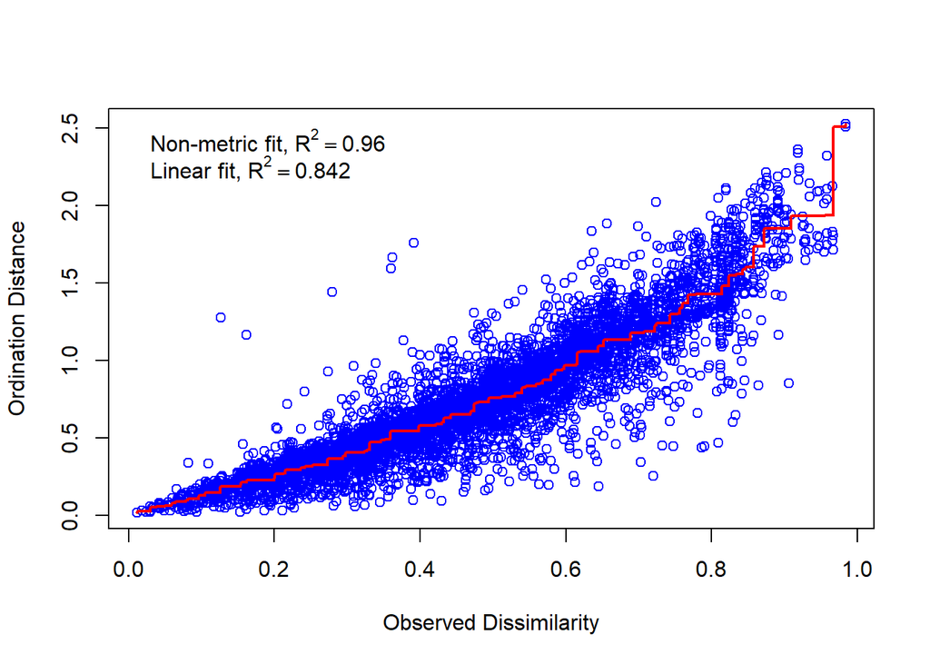

```r
stressplot(phyto_ord_bray)
```

```r
phyto_ord_bray$stress
```

```
## [1] 0.2007366
```

Regardless of the stress value, we can now plot our ordination. We can see that each lake is represented by a circle and the distance between each pair of lakes is our approximation of how dissimilar their phytoplankton communities are. Here, I also add a measure of the central location of different algal groups on this plot, although this is not generally considered very useful for interpretation.

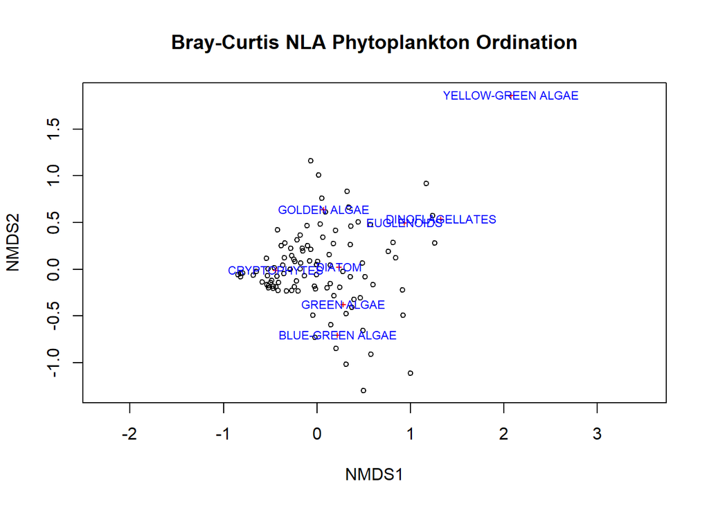

```r
plot(phyto_ord_bray, main = "Bray-Curtis NLA Phytoplankton Ordination")
  text(phyto_ord_bray, display ="spec", cex=0.7,col="blue")
```

Our ordination here is simply represented by pairs of points on these two meaningless axes as you can see below:

```r
scores(phyto_ord_bray)
```

```
## $sites
##                NMDS1        NMDS2
## 2010177 -0.646128331 -0.025786044
## 2010178  0.919378412 -0.495542795
## 2010179 -0.066015551  0.214140661
## 2010180 -0.350963487  0.119362272
## 2010181 -0.065871978  1.158685658
## 2010184 -0.280079401  0.225523928
## 2010186 -0.818685681 -0.045082203
## 2010187 -0.102091811  0.252724055
## 2010188  0.313365180 -1.019421975
## 2010189 -0.481610852 -0.120896748
## 2010193 -0.413034085 -0.143372235
## 2010194 -0.466706294 -0.180359321
## 2010195 -0.022108143 -0.730300894
```

[output cut: 98 more lines]

We can extract these values to plot in more dedicated graphics packages.

```r
phyto_bray_sites <- as.data.frame(scores(phyto_ord_bray)$sites)
head(phyto_bray_sites)
```

```
##               NMDS1       NMDS2
## 2010177 -0.64612833 -0.02578604
## 2010178  0.91937841 -0.49554280
## 2010179 -0.06601555  0.21414066
## 2010180 -0.35096349  0.11936227
## 2010181 -0.06587198  1.15868566
## 2010184 -0.28007940  0.22552393
```

We can also place our water chemistry or other environmental factors on this ordination and plot their vectors. Here, we see how each water chemistry variable correlates with our ordination plotting axes and test if they are significant (p-value < 0.05). The differences among the phytoplankton communities in these 100 lakes is signficantly correlated with pH, DOC, silica, and ammonia. The vectors show that the correlations for DOC, silica, and ammonia are all in the same ordination direction and so the individual contribution of each is not separable here (the analysis fits each variable separately).

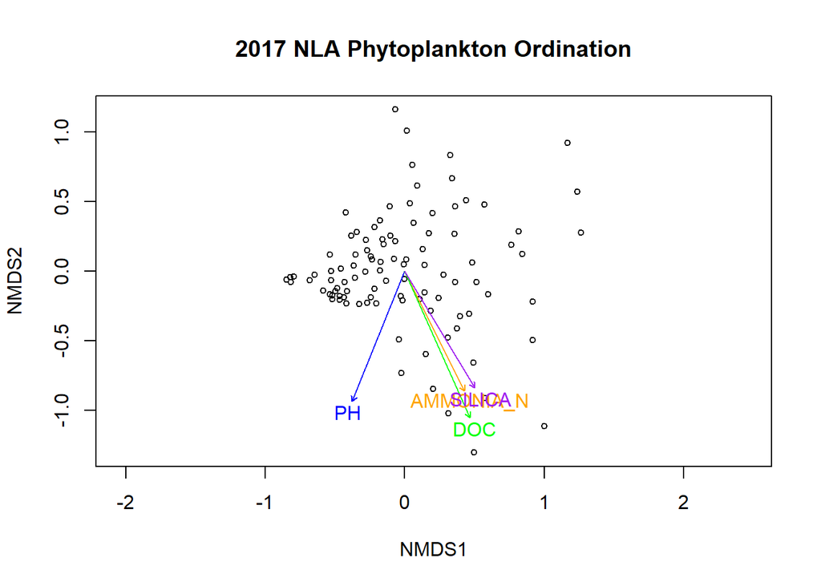

```r
ef <- envfit(phyto_ord_bray, chem[, -1], permu = 999)
plot(phyto_ord_bray, display = "sites", main = "2017 NLA Phytoplankton Ordination")
plot(ef, p.max=0.05, col = c("orange", "blue", "green", "purple"))
```

```r
ef
```

```
##
## ***VECTORS
##
##              NMDS1    NMDS2     r2 Pr(>r)
## AMMONIA_N  0.44555 -0.89526 0.1209  0.007 **
## NITRATE_N -0.99693 -0.07831 0.0160  0.475
## CHLA       0.99957 -0.02916 0.0407  0.130
## PH        -0.37486 -0.92708 0.1335  0.002 **
## DOC        0.40533 -0.91417 0.1739  0.002 **
## SILICA     0.51326 -0.85823 0.1250  0.005 **
## TURB      -0.98848  0.15134 0.0025  0.880
## ---
## Signif. codes:  0 '***' 0.001 '**' 0.01 '*' 0.05 '.' 0.1 ' ' 1
## Permutation: free
## Number of permutations: 999
```

We can also look at how groups of lakes cluster (or not) in their phytoplankton communities by environmental factors. First, let’s create a column called Hypereutrophic for lakes with chlorophyll above 50:

```r
phyto_scores = as.data.frame(scores(phyto_ord_bray)$sites)
phyto_scores$CHLA <- phyto_chem$CHLA
phyto_scores$Hypereutrophic <- phyto_scores$CHLA >= 50
```

We can now use our extracted ordination scores and this new column to plot any way we like, and specify our graphical parameters ourselves. For example, here we are color coding the lake ordination by whether or not the lake was hypereutrophic.

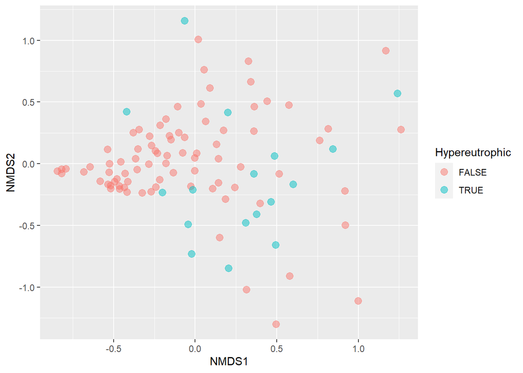

```r
ggplot(data = phyto_scores, aes(x = NMDS1, y = NMDS2)) +
     geom_point(data = phyto_scores, aes(colour = Hypereutrophic), size = 3, alpha = 0.5)
```

A common visualization technique for ordination is to draw hulls around groups. A basic convex hull simply draws connects all of the outer points for a group (like as if you stretched a rubber band around it). Below is a function to make a slightly smoothed hull around our above plot:

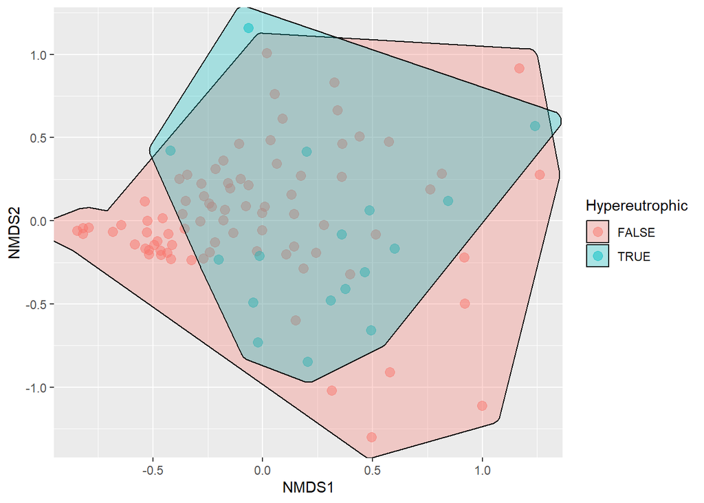

```r
ggplot(data = phyto_scores, aes(x = NMDS1, y = NMDS2)) +
     geom_point(data = phyto_scores, aes(colour = Hypereutrophic), size = 3, alpha = 0.5) +
      geom_mark_hull(data = phyto_scores,aes(fill = Hypereutrophic),concavity = 10)
```

Finally, we can do our cleanup to make a more presentation or manuscript worthy figure, which can take a bit of work in terms of lines of code and figuring out how to change graphic parameters. It its optional to do this cleanup for this exercise, but it is good practice for your final figure creation.

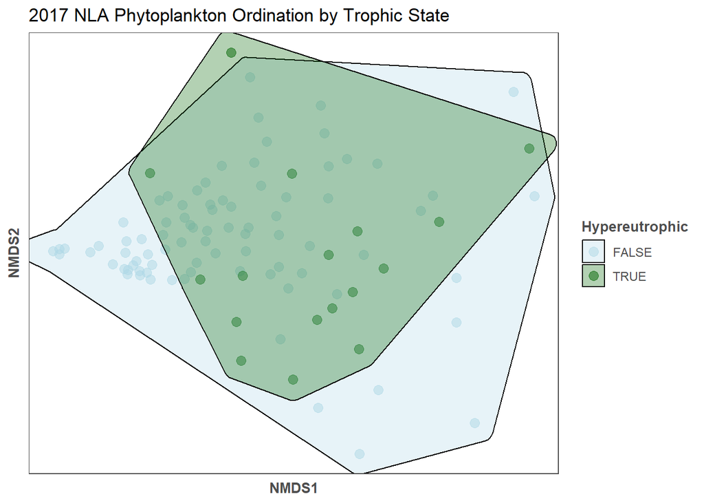

```r
ggplot(data = phyto_scores, aes(x = NMDS1, y = NMDS2)) +
     geom_point(data = phyto_scores, aes(colour = Hypereutrophic), size = 3, alpha = 0.5) +
     scale_colour_manual(values = c("lightblue", "darkgreen")) + ggtitle("2017 NLA Phytoplankton Ordination by Trophic State") +
     theme(axis.title = element_text(size = 10, face = "bold", colour = "grey30"),
     panel.background = element_blank(), panel.border = element_rect(fill = NA, colour = "grey30"),
     axis.ticks = element_blank(), axis.text = element_blank(), legend.key = element_blank(),
     legend.title = element_text(size = 10, face = "bold", colour = "grey30"),
     legend.text = element_text(size = 9, colour = "grey30")) +
     labs(colour = "Hypereutrophic")+
     geom_mark_hull(data = phyto_scores,aes(fill = Hypereutrophic),concavity = 10)+
     scale_fill_manual(values = c("lightblue", "darkgreen"))
```

## Exercise Questions (40 pts)

### Zooplankton Data Prep (5 pts)

Your goal will be to explore the zooplankton data from the 2017 NLA. First, we will prepare the data for ordination as above.

Read in the “nla-2017-zooplankton-count-data.csv” file into your R session using read.csv() (1 pts)

Trim the data to the 100 lakes subset in the “NLA_2017_Chemistry_Subset.csv” file using %in% and the UID columns (1 pts)

Remove all rows of data where the FAMILY for the zooplankton is blank. i.e., FAMILY == “” (1 pts)

Use dcast() or another function to convert this long data frame into wide based on the formula UID ~ FAMILY for the BIOMASS value.var and aggregating by the sum (1 pts).

Replace all NA values in your wide data frame (site by species) with a value of 0, indicating that no biomass of that family was found (1 pts)

### Site and Chemistry Data Merging (7 pts)

Next, we will make one large data frame that contains (a) our zooplankton data, (b) our water chemistry data, and (c) our site information data “nla_2017_site_information-data.csv”.

First, import the site information data as a new object using read.csv() (1 pts)

Trim the site information data to the 100 lakes in the water chemistry subset using %in% and the UID columns (1 pts)

Merge the water chemistry and site information data objects using the UID column using merge() or a similar function (2 pts)

To the merged chemistry and site object you just made, also merge the zooplankton data subset you created. Your final merged data frame here will have all three data sets in one object for your 100 lakes (3 pts)

### Plotting and Ordination (28 pts)

Make a boxplot of the biomass of the family DAPHNIIDAE (the family containing Daphnia) by whether or not the NLA classified the lake as urban in 2017 based on the URBN_NLA17 column in your merged data set. (4 pts)

Are DAPHNIIDAE in higher or lower biomass in lakes that are urban or non-urban in this subset? You may compare means or use t.test() if you would optionally like to perform a significance test (4 pts)

Investigate the biomass of DAPHNIIDAE versus the rotifer families TESTUDINELLIDAE and ASPLANCHNIDAE. You can either make two individual scatterplots or use the pairs() function to plot all the pairwise plots. The syntax for this would be pairs(your_object_name[, c(“DAPHNIIDAE”, “TESTUDINELLIDAE”, “ASPLANCHNIDAE”)]) (4 pts)

Broadly speaking, when do these rotifer families tend to have their greatest biomasses in the NLA zooplankton samples relative to the family containing Daphnia (2 pts)?

**Finally, you will perform an ordination on the zooplankton data using non-metric multidimensional scaling (NMDS).**

If you have not already, set the UID column of your wide zooplankton data to be the rowname as we did for the phytoplankton. You want to double-check that your matrix has lake UID as rownames and the zooplankton families as column names with only the biomass data within the data matrix (2 pts)

Use metaMDS() to calculate distance metrics among your zooplankton communities and calculate the ordination. You may use the Bray-Curtis distance as above, the Jaccard index we talked about in class, or another one of your choosing if you are adventurous (2 pts).

Make a stressplot() of your ordination (2 pts)

Create an NMDS plot for the 2017 NLA zooplankton data from your ordination that distinguishes among two or more types of lakes from your merged data sets (colors, hulls, etc.) **OR** plots environmental vectors. For example, you could continue looking at urban versus non-urban, or make groups for Ammonia concentrations, or something else of your choice entirely. (4 pts for NMDS plot; 2 pts for distinguishing lake types)

What conclusions can you draw, if any, about whether or not there are differences in zooplankton communities among your lake types (2 pts)